# A tutorial on applying Functional Principal Components Analysis (fPCA) in Matlab

John Warmenhoven, Norma Bargary, Dominik Liebl, Andrew Harrison, Mark Robinson, Edward Gunning & Giles Hooker

## Load sample data

Data for this tutorial can be taken from the Functional Data Analysis website: http://www.psych.mcgill.ca/misc/fda/downloads/FDAfuns/Matlab/ (once the fdaM.zip folder is downloaded, data is located at 'fdaM\examples\gait')

For any questions related to this tutorial (and script), please email john.warmenhoven@hotmail.com.

All content from this tutorial can be found in two key texts. All theoretical information underpinning the use of these processes can be found at Ramsay and Silverman (2005). Additionally, a useful text outlining computational approaches for applying these processes in Matlab and R can be found at Ramsay, Hooker and Graves (2009).

The data can be loaded below (make sure this is in the same folder as your m-file).

load('gait');

This loads open access data collected at the Motion Analysis Laboratory at Children’s Hospital in California. Full details on the collection of the data can be found at Olshen, et al. (1989).

The data consists of hip and knee joint curves of 39 children. Each curve consists of 20 data points across the gait cycle. This tutorial will only focus on the knee joint.

## Add file paths

The files for using FDA can be obtained from the software/download sections of the www.functionaldata.org website. The title of the folder containing the Matlab functions is "fdaM."

The software packages for Matlab are available and can be downloaded to a convenient location on your computer. The paths of these Matlab functions will need to be added before using these techniques.

Make sure to name the filepath correctly (see below):

addpath('E:\fdaM\')

## Functional Data Analysis (Preliminary Steps)

FDA involves a series of preliminary steps prior to applying any techniques. These are mainly centred around function fitting, smoothing processes and registration of data.

An example of function fitting and smoothing is included in this script, but registration was not necessary for this data set so was not included.

The knees have been normalised to 20 data points using an interpolating cublic spline. Here they are centered within the time interval (which in this case after temporal normalization is percentage of the gait cycle).

time = linspace(0, 100, 20)';

The next step involves representation of functions using a suitable basis expansion. This involves representing the observed curves as a linear (or weighted) combination of known functions (basis functions), where the coefficients (or weights) are chosen from the data.

FDA has options for a number of different bases (i.e. Fourier, B-splines, Wavelets, etc.). In this demonstration the functions were fitted using B-splines, which are commonly drawn upon for biomechanics data. Spline functions are the most common choice of expansion for non-periodic functional data, which constitutes many types of human movements (i.e. movements that are not necessarily cyclical).

To set up for function fitting with B-splines, a fourth-order spline (cubic spline) is selected, the maximum number of functions is selected (at 20 basis functions), given that a smoothing parameter will be added later to the function fitting process. Smoothness of the data can also be manipulated by the number of basis functions selected (less basis functions results in a smoother fit of the functions).

A cubic spline (spline of order 4) is selected as these are considered sufficient to approximate nearly all sufficiently smooth functions (with the knee angles in this tutorial being one example of this). If we were interested in velocity or acceleration, we may consider selecting a higher order spline (5th and 6th respectively).

kneebasis = create_bspline_basis([0,100], 20, 4);

When choosing the coefficients for the basis representation we want to penalise both fit to the observed data and roughness of our estimated function. Below we set up the penalty for roughness by defining a linear differential operator. This defines how we will smooth our data. If we want the original data to be smooth we penalise the second derivative, which is related directly to the curvature of our original data (and we do this by selecting 2 within the int2Lfd function). In this sense, Lfdobj is defining “what” is smooth.

Lfdobj = int2Lfd(2);

If we wanted to focus on the smoothness of our first derivative (knee angular velocity in this instance) we would penalize the third derivative. Similarly knee angular acceleration smoothness would require penalizing the fourth derivative.

We have defined how we plan to smooth the data, but before we can finish defining a functional parameter object, generalized cross validation (GCV) can be used to trial values of lambda (a smoothing parameter), to determine a suitable level of smoothing.

Lambda, also known as the roughness penalty parameter, controls the trade-off between the fit to the data and the roughness penalty we have defined. A large value of lambda would put more emphasis on the roughness penalty and result in a smoother estimated function. A smaller value would conversely put more emphasis on fit to the data and result in a less smooth estimated function.

The GCV criterion (defined within this loop as GCVsave) is a measure of the predictive error for different values of lambda, with this often being trialled across a range of potential values. This is the most common way to get an estimate for an appropriate value of lambda and was first defined by Craven and Wahba (1979).

Below is a for-loop for calculating GCV at a range of different values of lambda, varying between 100 and 1e-5 and being represented by lam.

lam = [100, 10, 1, 1e-1, 1e-2, 1e-3, 1e-4, 1e-5];

nlam = length(lam);

Gcvsave = zeros(nlam,1);

Dfsave = Gcvsave;

for ilam = 1:nlam

lambda = lam(ilam);

fdParobj = fdPar(kneebasis, Lfdobj, lambda);

[logknee_fd, logknee_df, logknee_gcv] = ...

smooth_basis(time, knee, fdParobj);

Dfsave(ilam) = logknee_df;

Gcvsave(ilam) = sum(logknee_gcv);

end

Here is a plot of the GCV criterion at different values of lambda.

figure(1);

title('Lambda Selection');

phdl=plot(lam, Gcvsave, 'ko-');

set(phdl, 'LineWidth', 1)

xlabel('\fontsize{13} \lambda')

ylabel('\fontsize{13} GCV(\lambda)')

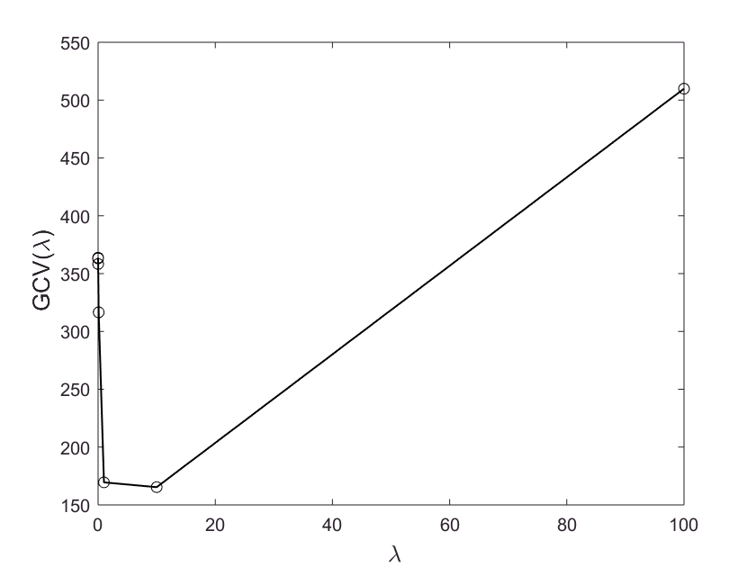

Given that the GCV criterion relates directly to the predictive error for different values of lambda, a good starting point for selecting a value for lambda is the smallest GCV value trialled in the minimization routine (which in this case was 10). This may not always work perfectly in practice and should always be confirmed through visual inspection (i.e. graphing the fitted data).

Now we can complete defining a functional parameter object smoothing and fitting the functions to the data. The results of GCV have suggested that a smoothing parameter of 10 may be suitable for this data.

smoothing_parameter = 10;

kneefdPar = fdPar(kneebasis, Lfdobj, smoothing_parameter);

The fdPar function serves as a way of capturing all the information required for function fitting and smoothing. This is inclusive of the expansion being used (in this case B-splines), what is being focused on for smoothing (in this case penalising the second derivative) and roughness penalty in the form of lambda (in this case a value of 10).

## Functional Principal Components Analysis (fPCA)

In fPCA we store all smoothed curves in the same functional data object using the smooth.basis function.

knee_fd = smooth_basis(time, knee, kneefdPar);

We have also listed the number of functional principal components to be retained as five.

nharm = 5;

Similar to the function fitting and smoothing processes described in the FDA (Preliminary Steps) section, it is also possible to smooth fPC functions as a part of describing them. This time a negligible smoothing parameter was selected (a very minimal penalty).

kneePCAfdPar = fdPar(kneebasis, Lfdobj, 1e-15);

knee_pcastr = pca_fd(knee_fd, nharm, kneePCAfdPar);

Most of these will come from a 'struct' that has been built as a part of the pca_fd function. In this case the struct is called knee_pcastr.

As an example the mean function (as a functional data object) can be called on using the following.

kneemeanfd = mean(knee_fd);

Similarly, the fPC functions (as functional data objects) can be called upon using the following.

kneeharmfd = knee_pcastr.harmfd;

We can also unwrap the mean function and fPC functions to a vector of points that can be used for graphical observation and plotting of results.

kneemeanvec = squeeze(eval_fd((time), kneemeanfd));

kneeharmmat = eval_fd(time, kneeharmfd);

We can also identify the amount of variation attributed to each fPC by exploring the varprop part of the struct.

kneevarprop = knee_pcastr.varprop;

kneescores = knee_pcastr.harmscr;

## Visualising Results

Similar to PCA, a constant can be created to scale fPCs before adding and substracting them from the mean. A constant that is commonly used is 1 or 2 standard deviations (SD) of the fPC scores, with these being calculated for each fPC.

stdevfPCscores = std(kneescores);

After this 1 SD is used to create the constant:

con1 = stdevfPCscores(1)*1;

And then scaled these fPCs are added and subtracted from the mean curve, to show positive and negative scoring deviations away from the mean for each fPC.

fPC1_Pos = kneemeanvec + con1.*(kneeharmmat(:,1));

fPC1_Neg = kneemeanvec - con1.*(kneeharmmat(:,1));

figure(2) shows fPC1, with positive scorers plotted using the '+' symbols and negative scorers plotted using the '-' symbols.

figure(2)

phdl = plot(time, kneemeanvec, 'k-');

set(phdl, 'LineWidth', 1)

hold on

phdl = text(time, fPC1_Pos, '+');

set(phdl, 'LineWidth', 1)

hold on

phdl = text(time, fPC1_Neg, '-');

set(phdl, 'LineWidth', 1)

hold off

box on

set(gca,'FontSize',10);

title('\fontsize{10} fPC1');

xlabel('\fontsize{10} Gait Cycle (%)')

ylabel('\fontsize{10} Knee Angle (°)')

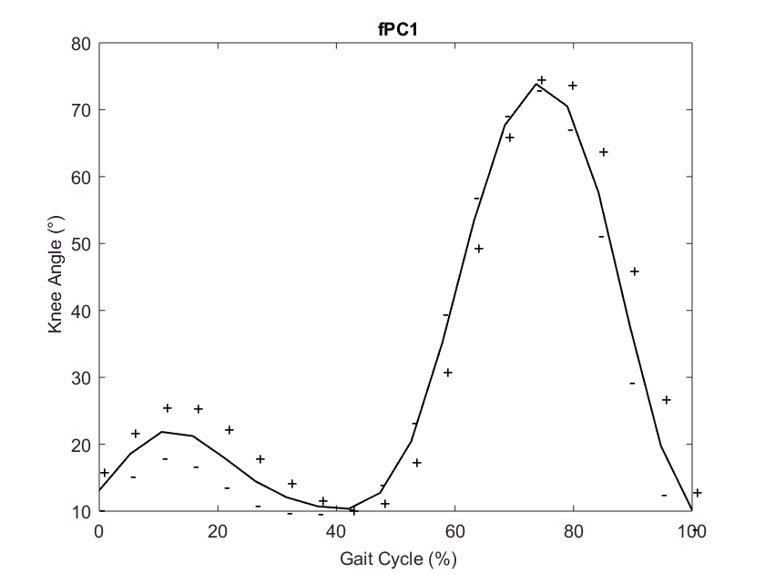

The same process is also carried out for fPC2. Inclusive of creating a constant to scale the fPCs.

con2 = stdevfPCscores(2)*1;

fPC2_Pos = kneemeanvec + con2.*(kneeharmmat(:,2));

fPC2_Neg = kneemeanvec - con2.*(kneeharmmat(:,2));

figure(3)

phdl = plot(time, kneemeanvec, 'k-');

set(phdl, 'LineWidth', 1)

hold on

phdl = text(time, fPC2_Pos, '+');

set(phdl, 'LineWidth', 1)

hold on

phdl = text(time, fPC2_Neg, '-');

set(phdl, 'LineWidth', 1)

hold off

box on

set(gca,'FontSize',10);

title('\fontsize{10} fPC2');

xlabel('\fontsize{10} Gait Cycle (%)')

ylabel('\fontsize{10} Knee Angle (°)')

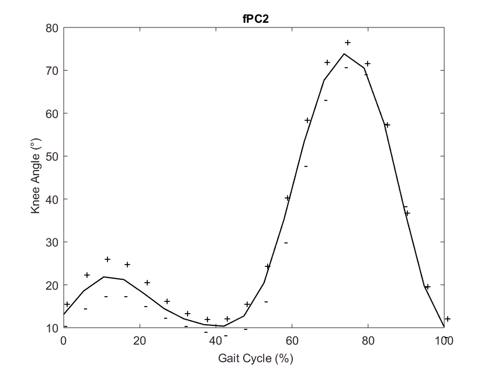

An example of a way to graph the principal component scores can also be seen below, plotting to scores for one fPC relative to another fPC.

figure(4)

phdl = scatter(kneescores(:,1),kneescores(:,2), 'k');

set(phdl, 'LineWidth', 1)

box on

set(gca,'FontSize',10);

title('\fontsize{10} fPC1 vs fPC2');

xlabel('\fontsize{10} fPC1 Scores')

ylabel('\fontsize{10} fPC2 Scores')

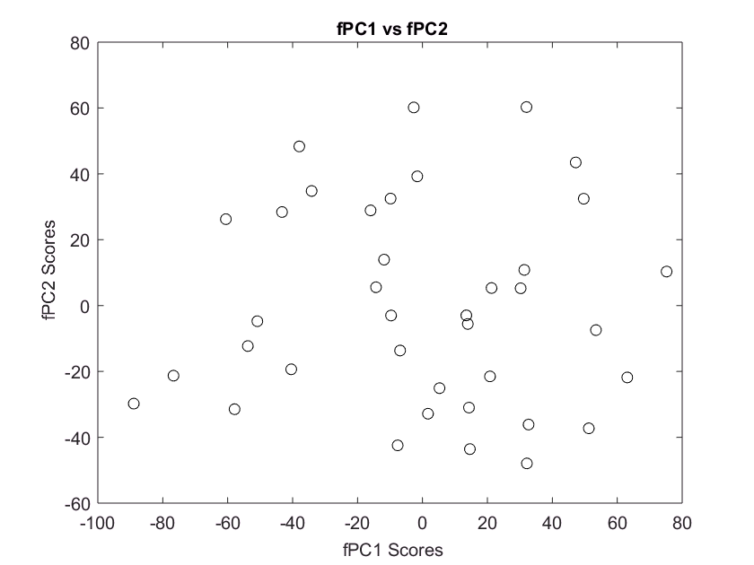

## Varimax Rotations

Varimax rotations are used to construct new components based on original principal components obtained from the above process of using fPCA. Varimax rotations maximize the variability of the squared principal component weights, for a selected group of fPCs. The resulting modes of variability tend to be concentrated on a part of the range of the function in question. Generally this focuses more acutely on areas of the curve within original fPCs, making the results sometimes more easier to interpret.

First we use the varmx_pca function, entering the knee.pcastr struct (from the original fPCA) as an input. knee.pcastr_vx is the outputted as a struct with rotated components and recalculated scores.

knee_pcastr_vx = varmx_pca(knee_pcastr);

We can now follow the same convention as before for visualising rotated components and scores.

kneeharmfd_vx = knee_pcastr_vx.harmfd;

kneeharmmat_vx = eval_fd(time, kneeharmfd_vx);

kneevarprop_vx = knee_pcastr_vx.varprop;

kneescores_vx = knee_pcastr_vx.harmscr;

stdevfPCscores_vx = std(kneescores_vx);

Below is the visual representation of rotated fPC1 & fPC2 in addition to the rotated scores for fPC1 & fPC2 plotted together.

con3 = stdevfPCscores_vx(1)*1;

fPC1_Pos_vx = kneemeanvec + con3.*(kneeharmmat_vx(:,1));

fPC1_Neg_vx = kneemeanvec - con3.*(kneeharmmat_vx(:,1));

figure(5)

phdl = plot(time, kneemeanvec, 'k-');

set(phdl, 'LineWidth', 1)

hold on

phdl = text(time, fPC1_Pos_vx, '+');

set(phdl, 'LineWidth', 1)

hold on

phdl = text(time, fPC1_Neg_vx, '-');

set(phdl, 'LineWidth', 1)

hold off

box on

set(gca,'FontSize',10);

title('\fontsize{10} fPC1 Varimax Rotated');

xlabel('\fontsize{10} Gait Cycle (%)')

ylabel('\fontsize{10} Knee Angle (°)')

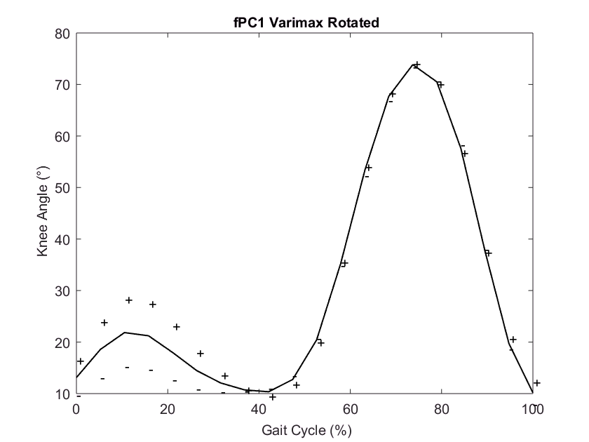

con4 = stdevfPCscores_vx(2)*1;

fPC2_Pos_vx = kneemeanvec + con4.*(kneeharmmat_vx(:,2));

fPC2_Neg_vx = kneemeanvec - con4.*(kneeharmmat_vx(:,2));

figure(6)

phdl = plot(time, kneemeanvec, 'k-');

set(phdl, 'LineWidth', 1)

hold on

phdl = text(time, fPC2_Pos_vx, '+');

set(phdl, 'LineWidth', 1)

hold on

phdl = text(time, fPC2_Neg_vx, '-');

set(phdl, 'LineWidth', 1)

hold off

box on

set(gca,'FontSize',10);

title('\fontsize{10} fPC2 Varimax Rotated');

xlabel('\fontsize{10} Gait Cycle (%)')

ylabel('\fontsize{10} Knee Angle (°)')

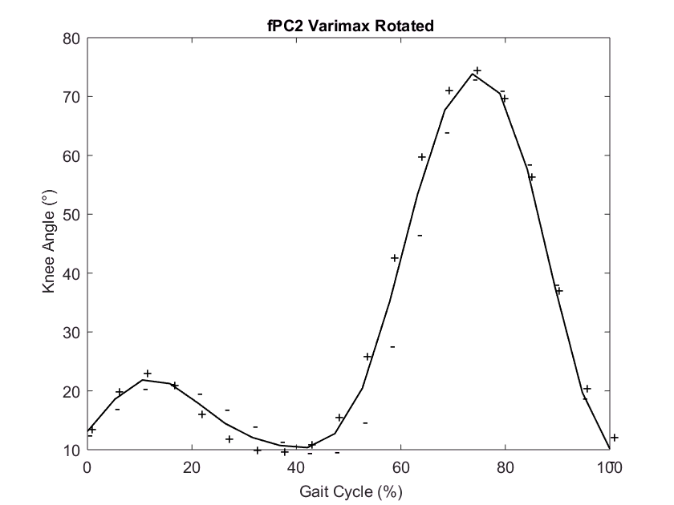

figure(7)

phdl = scatter(kneescores_vx(:,1),kneescores_vx(:,2), 'k');

set(phdl, 'LineWidth', 1)

box on

set(gca,'FontSize',10);

title('\fontsize{10} fPC1 Varimax vs fPC2 Varimax');

xlabel('\fontsize{10} fPC1 Scores')

ylabel('\fontsize{10} fPC2 Scores')

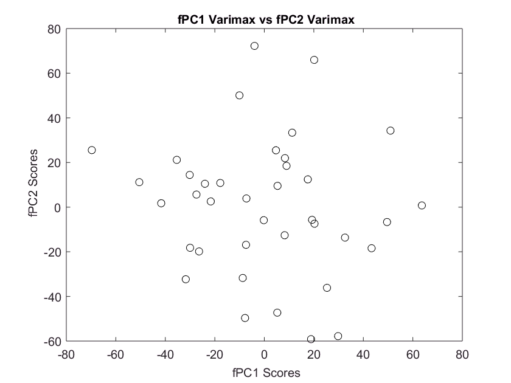

## References

Craven, P. & Wahba, G. (1979). Smoothing noisy data with spline functions: Estimating the correct degree of smoothing by the method of generalized crossvalidation. Numerische Mathematik 31, 377–403.

Olshen, R. A., Biden, E. N., Wyatt, M. P. & Sutherland, D. H. (1989). Gait analysis and the bootstrap. The Annals of Statistics, 1419-1440.

Ramsay, J. O., Hooker, G. & Graves, S. (2009). Functional data analysis with R and MATLAB, Springer, New York, NY.

Ramsay J. O. & Silverman B. W. Functional data analysis, Wiley Online Library; 2005.